# Reproducible Research: Peer Assessment 1

Margarette K.

## Loading and preprocessing the data

At first unzip and read our data.

```r
unzip("activity.zip", exdir = "data")
activity <- read.csv("data/activity.csv")
```

Now we have dataset called “activity”. Formatting dates from factors to dates. Take a look at it with summury function.

```r
activity$date <- as.Date(activity$date)
summary(activity)
```

```
##      steps            date               interval
##  Min.   :  0.0   Min.   :2012-10-01   Min.   :   0
##  1st Qu.:  0.0   1st Qu.:2012-10-16   1st Qu.: 589
##  Median :  0.0   Median :2012-10-31   Median :1178
##  Mean   : 37.4   Mean   :2012-10-31   Mean   :1178
##  3rd Qu.: 12.0   3rd Qu.:2012-11-15   3rd Qu.:1766
##  Max.   :806.0   Max.   :2012-11-30   Max.   :2355
##  NA's   :2304
```

## What is mean total number of steps taken per day?

Histigram of steps per date.

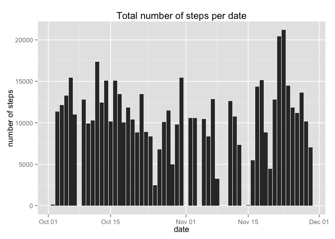

```r
library(ggplot2)
activity.by.date <- aggregate(steps ~ date, data = activity, FUN = sum)
qplot(date, steps, data=activity.by.date, geom = "histogram", stat = "identity", main = "Total number of steps per date", ylab = "number of steps")
```

The mean and median total number of steps taken per day.

```r
steps.mean <- aggregate(steps ~ date, data = activity, FUN = mean)
names(steps.mean) <- c("date", "mean_steps")
steps.median <- aggregate(steps ~ date, data = activity, FUN = median)
names(steps.median) <- c("date", "median_steps")
merge(steps.mean, steps.median)
```

```
##          date mean_steps median_steps
## 1  2012-10-02     0.4375            0
## 2  2012-10-03    39.4167            0
## 3  2012-10-04    42.0694            0
## 4  2012-10-05    46.1597            0
## 5  2012-10-06    53.5417            0
## 6  2012-10-07    38.2465            0
## 7  2012-10-09    44.4826            0
## 8  2012-10-10    34.3750            0
## 9  2012-10-11    35.7778            0
## 10 2012-10-12    60.3542            0
## 11 2012-10-13    43.1458            0
## 12 2012-10-14    52.4236            0
## 13 2012-10-15    35.2049            0
## 14 2012-10-16    52.3750            0
```

[output cut: 39 more lines]

## What is the average daily activity pattern?

Time series of 5 minute interval on the plot that illustrates activity height during a day.

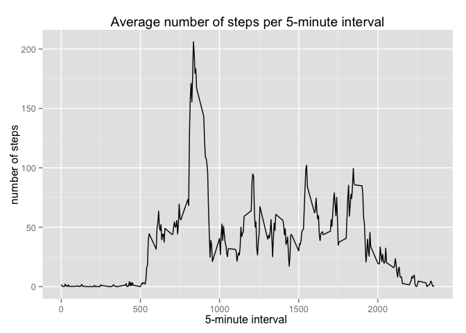

```r
activity.by.interval <- aggregate(steps ~ interval, data = activity, FUN = mean)
qplot(interval, steps, data=activity.by.interval, geom = "line", main = "Average number of steps per 5-minute interval", xlab = "5-minute interval ", ylab = "number of steps")
```

The 5-minute interval = 835, on average across all the days in the dataset, contains the maximum number of steps = 206.1698.

```r
library(plyr)
interval.max.desc <- arrange(activity.by.interval, desc(steps))
head(interval.max.desc)
```

```
##   interval steps
## 1      835 206.2
## 2      840 195.9
## 3      850 183.4
## 4      845 179.6
## 5      830 177.3
## 6      820 171.2
```

So, this is the time to go to work 8:35

## Imputing missing values

The total numer of NA in dataset = 2304.

```r
sum(is.na(activity))
```

```
## [1] 2304
```

Fill the NA’s with the mean for that 5-minute interval.

```r
activity.filled <- ldply(lapply(split(activity, as.factor(activity$date)), function(ad) {
  for(i in ad$interval) {
    if (is.na(ad[ad$interval == i, ]$steps)) {
      ad[ad$interval == i, ]$steps <- activity.by.interval[activity.by.interval$interval == i, ]$steps
    }
  }
  ad
}), data.frame)
activity.filled <- activity.filled[, 2:ncol(activity.filled)]
```

Histigram of steps per date.

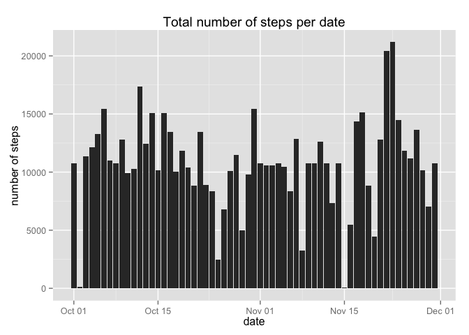

```r
library(ggplot2)
activity.by.date <- aggregate(steps ~ date, data = activity.filled, FUN = sum)
qplot(date, steps, data=activity.by.date, geom = "histogram", stat = "identity", main = "Total number of steps per date", ylab = "number of steps")
```

The mean and median total number of steps taken per day.

```r
steps.mean <- aggregate(steps ~ date, data = activity.filled, FUN = mean)
names(steps.mean) <- c("date", "mean_steps")
steps.median <- aggregate(steps ~ date, data = activity.filled, FUN = median)
names(steps.median) <- c("date", "median_steps")
merge(steps.mean, steps.median)
```

```
##          date mean_steps median_steps
## 1  2012-10-01    37.3826        34.11
## 2  2012-10-02     0.4375         0.00
## 3  2012-10-03    39.4167         0.00
## 4  2012-10-04    42.0694         0.00
## 5  2012-10-05    46.1597         0.00
## 6  2012-10-06    53.5417         0.00
## 7  2012-10-07    38.2465         0.00
## 8  2012-10-08    37.3826        34.11
## 9  2012-10-09    44.4826         0.00
## 10 2012-10-10    34.3750         0.00
## 11 2012-10-11    35.7778         0.00
## 12 2012-10-12    60.3542         0.00
## 13 2012-10-13    43.1458         0.00
## 14 2012-10-14    52.4236         0.00
```

[output cut: 47 more lines]

Now we have medians that are not zero.

## Are there differences in activity patterns between weekdays and weekends?

```r
activity.filled$day_type <- as.factor(as.numeric(weekdays(activity.filled$date) %in% c("Saturday", "Sunday")))
levels(activity.filled$day_type)[1] <- 'weekday'
levels(activity.filled$day_type)[2] <- 'weekend'
```

Plotting mean number of steps for weekdays and weekends separately.

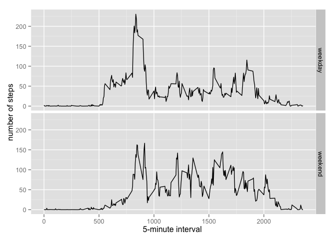

```r
activity.by.interval <- aggregate(steps ~ interval + day_type, data = activity.filled, FUN = mean)
qplot(interval, steps, data=activity.by.interval, geom = "line", xlab = "5-minute interval ", ylab = "number of steps", facets = day_type ~ .)
```

At weekends the man wakes up late. Activity during a weekend is smoother.